# introduction-to-text-analysis-in-r-chapter-2

Xiaotian Sun

09/02/2020

## 2. Visualizing Text

##### 2.1 Plotting word counts (video)

##### 2.2 Visualizing complaints

We ended the last chapter with complaint word counts. Now let’s visualize those word counts with a bar plot.

The `tidyverse` and `tidytext` packages have been loaded. `twitter_data` has been tokenized and the standard stop words have been removed.

```r
library(tidyverse)
library(tidytext)
twitter_data <- readRDS("ch_1_twitter_data.rds")

tidy_twitter <- twitter_data %>%
  # Tokenize the twitter data
  unnest_tokens(word, tweet_text) %>%
  # Remove stop words
  anti_join(stop_words)
```

*Instruction :*

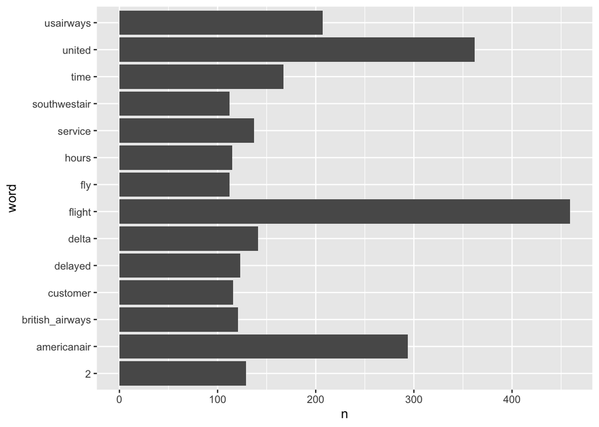

```r
word_counts <- tidy_twitter %>%
  filter(complaint_label == "Complaint") %>%
  count(word) %>%
  # Keep words with count greater than 100
  filter(n > 100)

# Create a bar plot using word_counts with x = word
ggplot(word_counts, aes(x = word, y = n)) +
  geom_col() +
  # Flip the plot coordinates
  coord_flip()
```

##### 2.3 Visualizing non-complaints

Now let’s visualize the word counts associated with non-complaints.

*Instruction :*

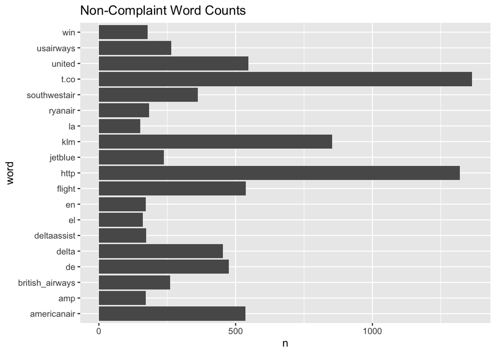

```r
word_counts <- tidy_twitter %>%
  # Only keep the non-complaints
  filter(complaint_label == 'Non-Complaint') %>%
  count(word) %>%
  filter(n > 150)

# Create a bar plot using the new word_counts
ggplot(word_counts, aes(x = word, y = n)) +
  geom_col() +
  coord_flip() +
  # Title the plot "Non-Complaint Word Counts"
  ggtitle("Non-Complaint Word Counts")
```

##### 2.4 Improving word count plots (video)

Categorical data is stored as the character type. However, there is another type used to store both categorical data in R: a factor. While in a character column, the words can be sorted alphabetically. However, a factor column can include information about the order in which words should appear.

`fct_reorder`

##### 2.5 Adding custom stop words

We’ve seen a number of words in `twitter_data` that aren’t informative and should be removed from your final list of words. In this exercise, you will add a few words to your `custom_stop_words` data frame .

*Instruction :*

```r
custom_stop_words <- tribble(
  # Column names should match stop_words
  ~word, ~lexicon,
  # Add http, win, and t.co as custom stop words
  "http", "CUSTOM",
  "win", "CUSTOM",
  "t.co", "CUSTOM"
)

# Bind the custom stop words to stop_words
stop_words2 <- stop_words %>%
  bind_rows(custom_stop_words)
```

##### 2.6 Visualizing word counts using factors

```r
tidy_twitter <- twitter_data %>%
  # Tokenize the twitter data
  unnest_tokens(word, tweet_text) %>%
  # Remove stop words
  anti_join(stop_words2)
```

*Instruction :*

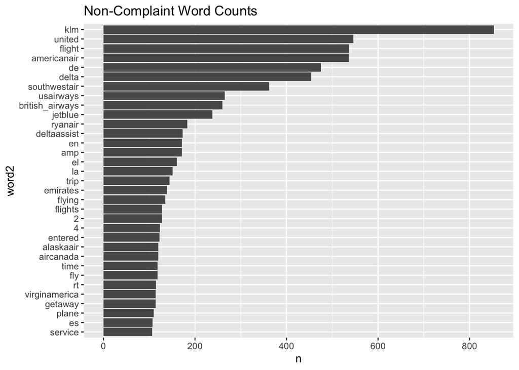

```r
word_counts <- tidy_twitter %>%
  filter(complaint_label == "Non-Complaint") %>%
  count(word) %>%
  # Keep terms that occur more than 100 times
  filter(n > 100) %>%
  # Reorder word as an ordered factor by word counts
  mutate(word2 = fct_reorder(word, n))

# Plot the new word column with type factor
ggplot(word_counts, aes(x = word2, y = n)) +
  geom_col() +
  coord_flip() +
  ggtitle("Non-Complaint Word Counts")
```

##### 2.7 Faceting word count plots (video)

- top_n()
- ungroup() removes the effect of group_by()
- geom_col(show.legend = FALSE)
- facet_warp(scales = “free_y”) The scales argument is also set to “free_y”, meaning the y-axis can be different for each plot.

##### 2.8 Counting by product and reordering

`tidy_twitter` has been tokenized and stop words, including custom stop words, have been removed. You would like to visualize the differences in word counts based on complaints and non-complaints.

*Instruction :*

```r
word_counts <- tidy_twitter %>%
  # Count words by whether or not its a complaint
  count(word, complaint_label) %>%
  # Group by whether or not its a complaint
  group_by(complaint_label) %>%
  # Keep the top 20 words
  top_n(20, n) %>%
  # Ungroup before reordering word as a factor by the count
  ungroup() %>%
  mutate(word2 = fct_reorder(word, n))
```

##### 2.9 Visualizing word counts with facets

The `word_counts` from the previous exercise have been loaded. Let’s visualize the word counts for the Twitter data with separate facets for complaints and non-complaints.

*Instruction :*

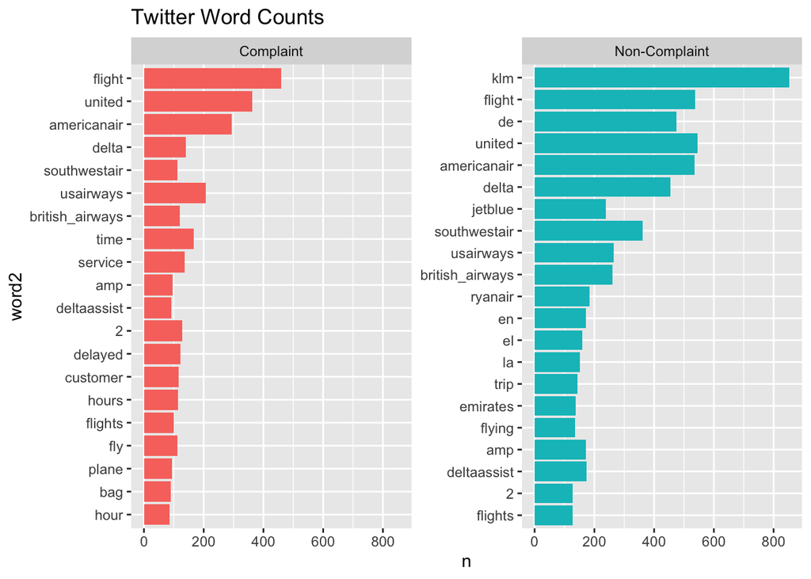

```r
# Include a color aesthetic tied to whether or not its a complaint
ggplot(word_counts, aes(x = word2, y = n, fill = complaint_label)) +
  # Don't include the lengend for the column plot
  geom_col(show.legend = FALSE) +
  # Facet by whether or not its a complaint and make the y-axis free
  facet_wrap(~complaint_label, scales = "free_y") +
  # Flip the coordinates and add a title: "Twitter Word Counts"
  coord_flip() +
  ggtitle("Twitter Word Counts")
```

##### 2.10 Plotting word clouds (video)

- wordcloud() is not part of tidyverse.
- freq, max.words, colors

##### 2.11 Creating a word cloud

We’ve seen bar plots, now let’s visualize word counts with word clouds! `tidy_twitter` has already been loaded, tokenized, and cleaned.

*Instruction :*

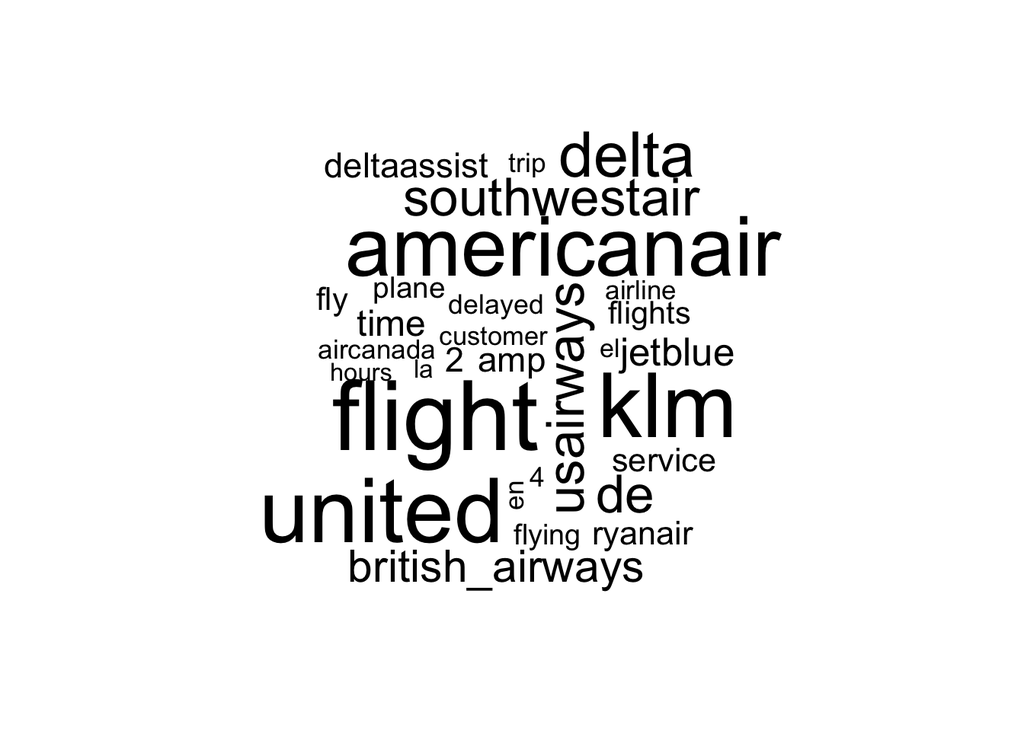

```r
# Load the wordcloud package
library(wordcloud)
# Compute word counts and assign to word_counts
word_counts <- tidy_twitter %>%
  count(word)

wordcloud(
  # Assign the word column to words
  words = word_counts$word,
  # Assign the count column to freq
  freq = word_counts$n,
  max.words = 30
)
```

*Notes:*

You may need to expand the plot in your browser to see any of the words clearly. The dominance of flight is readily apparent! We should consider whether or not this is another custom stop word.

##### 2.12 Adding a splash of color

What about just the complaints? And let’s add some color. Red seems appropriate. The `wordcloud` package has been loaded along with `tidy_twitter`.

*Instruction :*

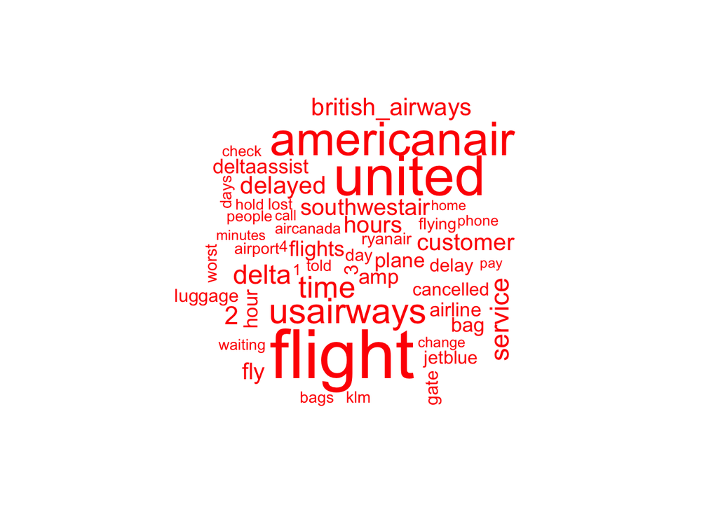

```r
# Compute complaint word counts and assign to word_counts
word_counts <- tidy_twitter %>%
  filter(complaint_label == "Complaint") %>%
  count(word)

# Create a complaint word cloud of the top 50 terms, colored red
wordcloud(
words = word_counts$word,
freq = word_counts$n,
max.words = 50,
colors = "red"
)
```